# Historical MAL - Cleaning Data

Edward Yu

March 6, 2019

# Introduction

If you are interested I have a small project for R, which is very useful. It has to do with history records of MAL. Here is some basic info:

- Goal: Clean up and consolidate dataset to enable easy searching of past melt records
- Tasks:
  - Mostly working with strings removing duplicates ( E. Yu, YU, Yu Edward …)
  - Removing empty records
  - Missing data
  - Multiple variables in one column

There might be other things to do but I have not spent much time looking at the dataset. We could also pull some basic stats on usage, costs, repeats etc. I don’t know your skill level, but it is relatively simple project and I am estimating it would take me about 8 hrs of work. Actual coding, if you know what to use, could be done in less than 1 hour but that requires proficiency in typing and in R.

I just noticed that sand for this year should have all been W410, excel incremented the name by 1 each time. I think I might be adding information about individual tests from this year incrementally as it comes in and since it is only several rows, perhaps you can delete the entire set of rows from this year, if that makes things easier on your end.

# Cleaning

This is a cleaning project. We need to:

1. clean
2. clean
3. clean
4. clean
5. clean…

## Preliminary exploration

There are a few key steps that are important before manipulating our data:

- Check the structure of our data
- Check the unique levels of our variables
- Determine which variables are missing data

### Import

There are a few things we see right off the bat.

- Redundant `ID` variable
- Poorly named variables (*e.g.* `lbs`, `Amount used`)
- Dates incorrectly formatted
- `Special Projects` potentially useless

```r
x <- read_csv("data/History.csv")
glimpse(x)
```

```
## Observations: 3,629
## Variables: 19
## $ Request              <int> 1, 2, 3, 4, 5, 6, 7, 8, 9, 10, 11, 12, 13, …
## $ ID                   <int> NA, NA, NA, NA, 12201, 12194, NA, NA, NA, N…
## $ `Date  Poured`       <chr> "1/5/1999", "1/6/1999", "1/7/1999", "1/8/19…
## $ `Date Received`      <chr> "1/4/1999", "1/4/1999", "1/4/1999", "1/4/19…
## $ `Date Completed`     <chr> "1/13/1999", "1/13/1999", "1/13/1999", "1/1…
## $ `Requested by`       <chr> "18", "CLINGERMAN,M.", "CLINGERMAN, M.", "C…
## $ `Customer Name`      <chr> "TS&D", "TS&D", "TS&D", "TS&D", "BRILLION",…
## $ `Product Tested`     <chr> "ISOCURE", "ISOCURE", "ISOCURE", "ISOCURE",…
## $ `Casting Type`       <chr> "STEPCONE", "STEPCONE", "EROSION WEDGE", "E…
## $ `Number of castings` <int> 8, 8, 8, 8, 3, 1, 8, 10, 8, 4, 10, 8, 2, 16…
## $ Alloy                <chr> "GRAY IRON", "GRAY IRON", "GRAY IRON", "GRA…
## $ lbs                  <int> 250, 250, 600, 600, 90, 90, 160, 30, 20, 10…
## $ `Sand type`          <chr> "TECHNISAND 1L-5W", "TECHNISAND 1L-5W", "TE…
## $ `Amount used`        <int> 840, 840, 1680, 1680, 270, 210, 640, 240, 1…
## $ `Total hours`        <chr> NA, NA, NA, NA, NA, NA, NA, NA, NA, NA, NA,…
## $ `Total Cost`         <dbl> 1300, 1300, 2210, 2210, 862, 715, 2080, 845…
## $ `Furnace Cycle`      <chr> "W68", "W69", "W70, W71", "W72, W73", "W74"…
## $ `Notes ML`           <chr> "TEST NEW BASE RESIN WITH STEPCONE CASTINGS…
## $ `Special Projects`   <chr> NA, NA, NA, NA, NA, NA, NA, NA, NA, NA, NA,…
```

### Get variable levels

Sorting by unique variable levels will give us an idea of how many unique datapoints we have in each variable category. We can make a few conclusions based on this information.

- `Request` is apprently doing the job of `ID`
- We likely do not have 273 unique types of castings, as suggested by `Casting type`
- We likely do not pour using 60 different alloys, as suggested by `Alloy`
- We see only 19 unique variables in `Special Projects`

```r
# FUNCTION to get levels by column
get_levels <- function(df, col){
  x.levels <- cbind(colnames(df),
                    (as.data.frame(sapply(df,function(x) length(unique(x)))))
  )
  colnames(x.levels) <- c("var","levels")
  row.names(x.levels) <- NULL
  levels <- x.levels[order(-x.levels[,2]),]
  return(levels[col,])
}

get_levels(x)
```

|  | var | levels |
| --- | --- | --- |
| 1 | Request | 3628 |
| 18 | Notes ML | 2902 |
| 3 | Date Poured | 2746 |
| 5 | Date Completed | 1989 |
| 4 | Date Received | 1962 |
| 17 | Furnace Cycle | 1718 |
| 2 | ID | 1623 |
| 7 | Customer Name | 373 |
| 9 | Casting Type | 273 |
| 6 | Requested by | 259 |

[output cut: 9 more lines]

### Visualize missing data

The naniar package makes visualization of missing data quite simple. Some of our previous observations come up again when looking at the plots.

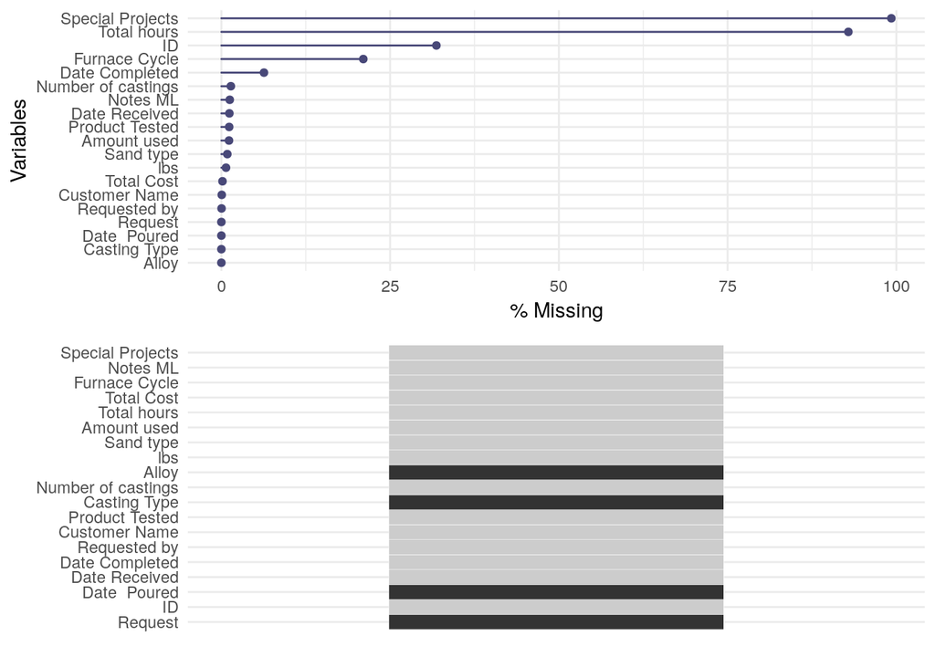

```r
# MISSING DATA
g1 <- gg_miss_var(x, show_pct = T)
g2 <- gg_miss_which(x)
grid.arrange(g1,g2,nrow=2)
```

### Rename variables

It’s best to convert all variable names to lowercase, remove spaces, and clarify the variable names.

```r
# RENAME VARIABLES
names <- tolower(colnames(x))
names <- gsub("  ", " ", names)
names <- gsub(" ", "\\.", names)
names[c(12,14)] <- c("alloy.lbs", "sand.lbs")
colnames(x) <- names
colnames(x)
```

```
##  [1] "request"            "id"                 "date.poured"
##  [4] "date.received"      "date.completed"     "requested.by"
##  [7] "customer.name"      "product.tested"     "casting.type"
## [10] "number.of.castings" "alloy"              "alloy.lbs"
## [13] "sand.type"          "sand.lbs"           "total.hours"
## [16] "total.cost"         "furnace.cycle"      "notes.ml"
## [19] "special.projects"
```

## Diving in

We look at each variable, specifically, and determine the best way of handling the data.

### Request

The `request` variable should be a unique, incremented identifier. This sounds like what the `id` variable was trying to accomplish. We’ll convert `request` values to row number values while also removing the `id` variable.

```r
# make request = row number, remove id
x <- x %>%
  mutate(request = seq(1:nrow(x))) %>%
  select(-id)
```

### Dates

As we’ll see, many of the dates are not chronologically accurate. For example, `date.poured` may come before `date.received`, `date.completed` may even come before `date.received`. To correct these cases we want to detect any situation which does not follow the pattern of `date.received` < `date.poured` < `date.completed`, and correct them.

1. Convert to `Date` format
2. Find & correct extreme outliers
3. Create new variables to further find outliers

```r
# convert to dates
x <- x %>%
  mutate(date.received  = as.Date(x$date.received,  "%m/%d/%Y")) %>%
  mutate(date.poured    = as.Date(x$date.poured,    "%m/%d/%Y")) %>%
  mutate(date.completed = as.Date(x$date.completed, "%m/%d/%Y"))

# check summary
summary(x[c(3,2,4)])
```

```
##  date.received         date.poured         date.completed
##  Min.   :1990-10-20   Min.   :1995-08-04   Min.   :1999-01-13
##  1st Qu.:2001-07-27   1st Qu.:2001-08-08   1st Qu.:2001-10-31
##  Median :2005-06-08   Median :2005-07-11   Median :2005-09-23
##  Mean   :2006-02-25   Mean   :2006-03-03   Mean   :2006-04-11
##  3rd Qu.:2010-03-31   3rd Qu.:2010-05-18   3rd Qu.:2010-06-11
##  Max.   :2513-11-01   Max.   :2078-08-24   Max.   :2106-04-05
##  NA's   :43           NA's   :1            NA's   :229
```

```r
# filter for anything too far in the future
wrong.dates <- x %>%
  filter(date.received  > "2020-01-01" |
         date.poured    > "2020-01-01" |
         date.completed > "2020-01-01")

as.data.frame(wrong.dates)[,c(1,3,2,4)]
```

| request | date.received | date.poured | date.completed |
| --- | --- | --- | --- |
| 1103 | 2002-04-12 | 2020-04-30 | 2002-05-03 |
| 1198 | 2002-07-02 | 2002-08-02 | 2020-08-22 |
| 1889 | 2021-11-17 | 2005-11-21 | 2005-11-23 |
| 2735 | 2010-06-04 | 2020-06-10 | 2010-06-11 |
| 2740 | 2021-06-15 | 2010-06-21 | 2010-06-22 |
| 3106 | 2021-03-20 | 2012-03-21 | 2012-03-22 |
| 3149 | 2023-06-19 | 2012-06-26 | 2012-06-27 |
| 3341 | 2513-11-01 | 2013-11-22 | 2013-12-02 |
| 3582 | 2016-03-16 | 2016-04-01 | 2106-04-05 |
| 3606 |  | 2078-08-24 |  |

```r
# manually fix
x$date.poured[1103]    <- as.Date("2002-04-30")
x$date.completed[1198] <- as.Date("2002-08-22")
x$date.received[1889]  <- as.Date("2005-11-17")
x$date.poured[2735]    <- as.Date("2002-06-10")
x$date.received[2740]  <- as.Date("2010-06-15")
x$date.received[3106]  <- as.Date("2012-03-20")
x$date.received[3149]  <- as.Date("2012-06-19")
x$date.received[3341]  <- as.Date("2013-11-01")
x$date.completed[3582] <- as.Date("2016-04-05")
x$date.poured[3606]    <- as.Date("2017-08-24")

# dates now seem to be in a normal range
summary(x[c(3,2,4)])
```

```
##  date.received         date.poured         date.completed
##  Min.   :1990-10-20   Min.   :1995-08-04   Min.   :1999-01-13
##  1st Qu.:2001-07-27   1st Qu.:2001-08-08   1st Qu.:2001-10-31
##  Median :2005-06-08   Median :2005-07-07   Median :2005-09-20
##  Mean   :2005-12-31   Mean   :2006-02-21   Mean   :2006-03-30
##  3rd Qu.:2010-03-30   3rd Qu.:2010-05-17   3rd Qu.:2010-06-10
##  Max.   :2016-04-25   Max.   :2018-11-28   Max.   :2016-05-02
##  NA's   :43           NA's   :1            NA's   :229
```

We’ve fixed the obvious outliers, we need to fix chronological errors now. Easiest way to do this is to come up with aa few new metrics:

- *Pre-processing time* days between `date.received` and `date.poured`
- *Post-processing time* days between `date.poured` and `date.completed`
- *Lead time* days between `date.received` and `date.completed`

Any abnormal values resulting from calculation of these variables will tell us that something at least one variable is not following: `date.received` < `date.poured` < `date.completed`.

```r
# function to calculate times based on date values
## preprocessing  = time between receiving and pouring
## postprocessing = time between pouring and completed
## lead time      = pre + post-processing
calc_lead <- function(){
  preprocessing.time  <- as.numeric(x$date.poured-x$date.received)
  postprocessing.time <- as.numeric(x$date.completed-x$date.poured)
  lead.time           <- preprocessing.time + postprocessing.time
  x.temp <- as_tibble(cbind(x,
                            preprocessing.time,
                            postprocessing.time,
                            lead.time))
  return(x.temp)
}

summary(calc_lead()[c(19:21)])
```

```
##  preprocessing.time postprocessing.time   lead.time
##  Min.   :-3288.00   Min.   :-4014.000   Min.   :-4011.000
##  1st Qu.:    3.00   1st Qu.:    1.000   1st Qu.:    5.000
##  Median :    5.00   Median :    2.000   Median :    8.000
##  Mean   :    5.74   Mean   :    3.641   Mean   :    8.176
##  3rd Qu.:    8.00   3rd Qu.:    5.000   3rd Qu.:   14.000
##  Max.   : 3293.00   Max.   : 3288.000   Max.   : 2804.000
##  NA's   :43         NA's   :229         NA's   :232
```

```r
# list large positive values
wrong.dates <- calc_lead() %>%
  filter(preprocessing.time  > 400 |
         postprocessing.time > 400)
wrong.dates[c(1,3,2,4)]
```

| request | date.received | date.poured | date.completed |
| --- | --- | --- | --- |
| 310 | 1990-10-20 | 1999-10-21 |  |
| 930 | 2001-08-24 | 2010-08-30 | 2001-09-04 |
| 1091 | 2002-04-09 | 2001-04-22 | 2002-07-12 |
| 1616 | 2000-04-13 | 2004-04-21 | 2004-04-26 |
| 1668 | 2004-08-04 | 1995-08-04 | 2004-08-04 |
| 1877 | 2005-10-31 | 2003-11-01 | 2005-11-14 |
| 2229 | 2000-01-07 | 2007-09-11 | 2007-09-11 |
| 2735 | 2010-06-04 | 2002-06-10 | 2010-06-11 |
| 3133 | 2012-05-16 | 2010-05-17 | 2012-05-18 |

```r
# manually fix
x$date.received[310]  <- as.Date("1999-10-20")
x$date.poured[930]    <- as.Date("2001-08-30")
x$date.poured[1091]   <- as.Date("2002-04-22")
x$date.received[1616] <- as.Date("2004-04-13")
x$date.poured[1668]   <- as.Date("2004-08-04")
x$date.poured[1877]   <- as.Date("2005-11-01")
x$date.received[2229] <- as.Date("2007-01-07")
x$date.poured[2735]   <- as.Date("2010-06-10")
x$date.poured[3133]   <- as.Date("2012-05-17")

# max values look better now
summary(calc_lead()[c(19:21)])
```

```
##  preprocessing.time  postprocessing.time   lead.time
##  Min.   :-3283.000   Min.   :-4014.000   Min.   :-4011.000
##  1st Qu.:    3.000   1st Qu.:    1.000   1st Qu.:    5.000
##  Median :    5.000   Median :    2.000   Median :    8.000
##  Mean   :    5.028   Mean   :    2.244   Mean   :    6.993
##  3rd Qu.:    8.000   3rd Qu.:    5.000   3rd Qu.:   14.000
##  Max.   :  374.000   Max.   :  383.000   Max.   :  434.000
##  NA's   :43          NA's   :229         NA's   :232
```

```r
# fix large negative values
wrong.dates <- calc_lead() %>%
  filter(preprocessing.time  < 0 |
         postprocessing.time < 0)

wrong.dates[c(1,3,2,4)]
```

| request | date.received | date.poured | date.completed |
| --- | --- | --- | --- |
| 13 | 1999-01-15 | 1999-01-19 | 1999-01-17 |
| 40 | 1999-02-27 | 1999-02-23 | 1999-02-24 |
| 41 | 1999-02-27 | 1999-02-24 | 1999-02-25 |
| 191 | 1999-07-06 | 1999-07-08 | 1999-06-29 |
| 314 | 1999-10-26 | 1999-10-27 | 1999-10-26 |
| 398 | 2000-12-22 | 2000-01-26 |  |
| 424 | 2000-03-10 | 2000-02-16 | 2000-02-24 |
| 448 | 2000-03-06 | 2000-03-10 | 2000-03-06 |
| 457 | 2000-03-17 | 2000-03-20 | 2000-03-18 |
| 458 | 2000-03-16 | 2000-03-21 | 2000-03-17 |

[output cut: 234 more lines]

We have a far larger amount of errors resulting in larger negative `lead.time`, etc, values (244), far too many to fix manually. This time, instead of fixing manually, we will extract these incorrect values from the original dataset, calculate average lead times on the remaining data, take the median value, and back-calculate the correct dates based on these measures.

```r
# extract all rows listed
# calculate average lead times on remaining dataset,
# insert dates into removed dataset, merge

x.anti <- anti_join(calc_lead(), wrong.dates, c("request"))

# anti looks good
summary(x.anti[c(19:21)])
```

```
##  preprocessing.time postprocessing.time   lead.time
##  Min.   :  0.000    Min.   :  0.000     Min.   :  0.00
##  1st Qu.:  3.000    1st Qu.:  1.000     1st Qu.:  6.00
##  Median :  6.000    Median :  3.000     Median :  9.00
##  Mean   :  8.141    Mean   :  5.218     Mean   : 13.11
##  3rd Qu.:  8.000    3rd Qu.:  6.000     3rd Qu.: 14.00
##  Max.   :372.000    Max.   :308.000     Max.   :434.00
##  NA's   :43         NA's   :225         NA's   :228
```

```r
# wrongs look bad
summary(wrong.dates[c(19:21)])
```

```
##  preprocessing.time postprocessing.time   lead.time
##  Min.   :-3283.00   Min.   :-4014.00    Min.   :-4011.00
##  1st Qu.:  -13.00   1st Qu.:    0.00    1st Qu.:  -12.00
##  Median :   -7.00   Median :    1.00    Median :   -5.00
##  Mean   :  -37.62   Mean   :  -36.91    Mean   :  -73.52
##  3rd Qu.:   -1.00   3rd Qu.:    3.00    3rd Qu.:    0.00
##  Max.   :  374.00   Max.   :  383.00    Max.   :   27.00
##                     NA's   :4           NA's   :4
```

```r
# see some NA values from the calculations
# backtrace to check dates
summary(wrong.dates[c(3,2,4)])
```

```
##  date.received         date.poured         date.completed
##  Min.   :1999-01-15   Min.   :1999-01-19   Min.   :1999-01-17
##  1st Qu.:2012-07-27   1st Qu.:2012-09-24   1st Qu.:2012-10-07
##  Median :2013-12-25   Median :2013-12-18   Median :2013-12-26
##  Mean   :2012-03-08   Mean   :2012-01-30   Mean   :2012-01-29
##  3rd Qu.:2014-10-15   3rd Qu.:2014-10-10   3rd Qu.:2014-10-11
##  Max.   :2016-02-24   Max.   :2016-02-25   Max.   :2016-02-24
##                                            NA's   :4
```

```r
# have NA values in date.completed
# if NA change completed date to received + 9

# > summary(x.anti[c(19:21)])
# preprocessing.time postprocessing.time   lead.time
# Median :  6.000    Median :  3.000     Median :  9.00

for (i in 1:dim(wrong.dates)[1]){
  if (is.na(wrong.dates$date.completed[[i]]) == TRUE){
    wrong.dates$date.completed[[i]] <- wrong.dates$date.received[[i]] + 9
  }
}
# no more NA's
summary(wrong.dates[c(3,2,4)])
```

```
##  date.received         date.poured         date.completed
##  Min.   :1999-01-15   Min.   :1999-01-19   Min.   :1999-01-17
##  1st Qu.:2012-07-27   1st Qu.:2012-09-24   1st Qu.:2012-07-24
##  Median :2013-12-25   Median :2013-12-18   Median :2013-12-22
##  Mean   :2012-03-08   Mean   :2012-01-30   Mean   :2011-12-27
##  3rd Qu.:2014-10-15   3rd Qu.:2014-10-10   3rd Qu.:2014-10-11
##  Max.   :2016-02-24   Max.   :2016-02-25   Max.   :2016-02-24
```

```r
# now we fix errors in chronology causing negative time calculations
summary(wrong.dates[c(19:21)])
```

```
##  preprocessing.time postprocessing.time   lead.time
##  Min.   :-3283.00   Min.   :-4014.00    Min.   :-4011.00
##  1st Qu.:  -13.00   1st Qu.:    0.00    1st Qu.:  -12.00
##  Median :   -7.00   Median :    1.00    Median :   -5.00
##  Mean   :  -37.62   Mean   :  -36.91    Mean   :  -73.52
##  3rd Qu.:   -1.00   3rd Qu.:    3.00    3rd Qu.:    0.00
##  Max.   :  374.00   Max.   :  383.00    Max.   :   27.00
##                     NA's   :4           NA's   :4
```

```r
# start with received coming before poured
wrong.dates$date.received > wrong.dates$date.poured
```

```
##   [1] FALSE  TRUE  TRUE FALSE FALSE  TRUE  TRUE FALSE FALSE FALSE FALSE
##  [12] FALSE FALSE FALSE  TRUE  TRUE  TRUE  TRUE FALSE FALSE FALSE FALSE
##  [23] FALSE FALSE  TRUE FALSE FALSE  TRUE FALSE FALSE FALSE FALSE FALSE
##  [34] FALSE FALSE FALSE  TRUE FALSE FALSE FALSE  TRUE FALSE  TRUE  TRUE
##  [45] FALSE FALSE FALSE FALSE FALSE FALSE FALSE FALSE  TRUE FALSE FALSE
##  [56] FALSE  TRUE  TRUE  TRUE FALSE  TRUE  TRUE FALSE  TRUE FALSE  TRUE
##  [67]  TRUE  TRUE  TRUE  TRUE  TRUE  TRUE  TRUE  TRUE  TRUE  TRUE  TRUE
##  [78]  TRUE  TRUE  TRUE  TRUE  TRUE  TRUE  TRUE  TRUE  TRUE  TRUE  TRUE
##  [89]  TRUE  TRUE  TRUE  TRUE  TRUE  TRUE  TRUE  TRUE  TRUE  TRUE  TRUE
## [100]  TRUE  TRUE  TRUE  TRUE  TRUE  TRUE  TRUE  TRUE  TRUE  TRUE  TRUE
## [111]  TRUE  TRUE  TRUE  TRUE  TRUE  TRUE  TRUE  TRUE  TRUE  TRUE  TRUE
## [122]  TRUE FALSE  TRUE  TRUE  TRUE  TRUE  TRUE  TRUE  TRUE  TRUE  TRUE
## [133]  TRUE  TRUE  TRUE  TRUE  TRUE  TRUE  TRUE  TRUE  TRUE  TRUE  TRUE
## [144]  TRUE  TRUE  TRUE  TRUE  TRUE  TRUE  TRUE  TRUE  TRUE  TRUE  TRUE
## [155]  TRUE  TRUE  TRUE  TRUE  TRUE  TRUE  TRUE  TRUE  TRUE  TRUE  TRUE
## [166]  TRUE  TRUE  TRUE  TRUE  TRUE  TRUE  TRUE  TRUE  TRUE  TRUE  TRUE
## [177]  TRUE  TRUE  TRUE  TRUE  TRUE  TRUE  TRUE  TRUE  TRUE  TRUE  TRUE
## [188]  TRUE  TRUE  TRUE  TRUE  TRUE  TRUE  TRUE  TRUE  TRUE  TRUE  TRUE
## [199]  TRUE  TRUE  TRUE  TRUE  TRUE  TRUE  TRUE  TRUE  TRUE  TRUE  TRUE
## [210]  TRUE  TRUE  TRUE  TRUE  TRUE  TRUE  TRUE  TRUE  TRUE  TRUE  TRUE
## [221]  TRUE  TRUE  TRUE  TRUE  TRUE  TRUE  TRUE  TRUE  TRUE  TRUE  TRUE
## [232]  TRUE  TRUE  TRUE  TRUE  TRUE  TRUE  TRUE  TRUE  TRUE  TRUE  TRUE
## [243]  TRUE FALSE
```

```r
wrong.dates[c(2,3,6,7),c(3,2,4)]
```

| date.received | date.poured | date.completed |
| --- | --- | --- |
| 1999-02-27 | 1999-02-23 | 1999-02-24 |
| 1999-02-27 | 1999-02-24 | 1999-02-25 |
| 2000-12-22 | 2000-01-26 | 2000-12-31 |
| 2000-03-10 | 2000-02-16 | 2000-02-24 |

```r
# then completed coming before poured
wrong.dates$date.poured > wrong.dates$date.completed
```

```
##   [1]  TRUE FALSE FALSE  TRUE  TRUE FALSE FALSE  TRUE  TRUE  TRUE  TRUE
##  [12]  TRUE  TRUE  TRUE FALSE FALSE FALSE FALSE  TRUE  TRUE  TRUE  TRUE
##  [23]  TRUE  TRUE FALSE  TRUE  TRUE FALSE  TRUE  TRUE  TRUE  TRUE  TRUE
##  [34]  TRUE  TRUE  TRUE FALSE  TRUE  TRUE  TRUE FALSE  TRUE FALSE FALSE
##  [45]  TRUE  TRUE  TRUE  TRUE  TRUE  TRUE  TRUE  TRUE FALSE  TRUE  TRUE
##  [56]  TRUE FALSE FALSE FALSE  TRUE FALSE FALSE  TRUE FALSE  TRUE FALSE
##  [67] FALSE FALSE FALSE FALSE FALSE FALSE FALSE FALSE FALSE FALSE FALSE
##  [78] FALSE FALSE FALSE FALSE FALSE FALSE FALSE FALSE FALSE FALSE FALSE
##  [89] FALSE FALSE FALSE FALSE FALSE FALSE FALSE FALSE FALSE FALSE FALSE
## [100] FALSE FALSE FALSE FALSE FALSE FALSE FALSE FALSE FALSE FALSE FALSE
## [111] FALSE FALSE FALSE FALSE FALSE FALSE FALSE FALSE FALSE FALSE FALSE
## [122] FALSE  TRUE FALSE FALSE FALSE FALSE FALSE FALSE FALSE FALSE FALSE
## [133] FALSE FALSE FALSE FALSE FALSE FALSE FALSE FALSE FALSE FALSE FALSE
## [144] FALSE FALSE FALSE FALSE FALSE FALSE FALSE FALSE FALSE FALSE FALSE
## [155] FALSE FALSE FALSE FALSE FALSE FALSE FALSE FALSE FALSE FALSE FALSE
## [166] FALSE FALSE FALSE FALSE FALSE FALSE FALSE FALSE FALSE FALSE FALSE
## [177] FALSE FALSE FALSE FALSE FALSE FALSE FALSE FALSE FALSE FALSE FALSE
## [188] FALSE FALSE FALSE FALSE FALSE FALSE FALSE FALSE FALSE FALSE FALSE
## [199] FALSE FALSE FALSE FALSE FALSE FALSE FALSE FALSE  TRUE FALSE FALSE
## [210] FALSE FALSE FALSE FALSE FALSE FALSE FALSE FALSE FALSE FALSE FALSE
## [221] FALSE FALSE FALSE FALSE FALSE FALSE FALSE FALSE FALSE FALSE FALSE
## [232] FALSE FALSE FALSE FALSE FALSE FALSE FALSE FALSE FALSE FALSE FALSE
## [243] FALSE  TRUE
```

```r
wrong.dates$date.completed < wrong.dates$date.poured
```

```
##   [1]  TRUE FALSE FALSE  TRUE  TRUE FALSE FALSE  TRUE  TRUE  TRUE  TRUE
##  [12]  TRUE  TRUE  TRUE FALSE FALSE FALSE FALSE  TRUE  TRUE  TRUE  TRUE
##  [23]  TRUE  TRUE FALSE  TRUE  TRUE FALSE  TRUE  TRUE  TRUE  TRUE  TRUE
##  [34]  TRUE  TRUE  TRUE FALSE  TRUE  TRUE  TRUE FALSE  TRUE FALSE FALSE
##  [45]  TRUE  TRUE  TRUE  TRUE  TRUE  TRUE  TRUE  TRUE FALSE  TRUE  TRUE
##  [56]  TRUE FALSE FALSE FALSE  TRUE FALSE FALSE  TRUE FALSE  TRUE FALSE
##  [67] FALSE FALSE FALSE FALSE FALSE FALSE FALSE FALSE FALSE FALSE FALSE
##  [78] FALSE FALSE FALSE FALSE FALSE FALSE FALSE FALSE FALSE FALSE FALSE
##  [89] FALSE FALSE FALSE FALSE FALSE FALSE FALSE FALSE FALSE FALSE FALSE
## [100] FALSE FALSE FALSE FALSE FALSE FALSE FALSE FALSE FALSE FALSE FALSE
## [111] FALSE FALSE FALSE FALSE FALSE FALSE FALSE FALSE FALSE FALSE FALSE
## [122] FALSE  TRUE FALSE FALSE FALSE FALSE FALSE FALSE FALSE FALSE FALSE
## [133] FALSE FALSE FALSE FALSE FALSE FALSE FALSE FALSE FALSE FALSE FALSE
## [144] FALSE FALSE FALSE FALSE FALSE FALSE FALSE FALSE FALSE FALSE FALSE
## [155] FALSE FALSE FALSE FALSE FALSE FALSE FALSE FALSE FALSE FALSE FALSE
## [166] FALSE FALSE FALSE FALSE FALSE FALSE FALSE FALSE FALSE FALSE FALSE
## [177] FALSE FALSE FALSE FALSE FALSE FALSE FALSE FALSE FALSE FALSE FALSE
## [188] FALSE FALSE FALSE FALSE FALSE FALSE FALSE FALSE FALSE FALSE FALSE
## [199] FALSE FALSE FALSE FALSE FALSE FALSE FALSE FALSE  TRUE FALSE FALSE
## [210] FALSE FALSE FALSE FALSE FALSE FALSE FALSE FALSE FALSE FALSE FALSE
## [221] FALSE FALSE FALSE FALSE FALSE FALSE FALSE FALSE FALSE FALSE FALSE
## [232] FALSE FALSE FALSE FALSE FALSE FALSE FALSE FALSE FALSE FALSE FALSE
## [243] FALSE  TRUE
```

```r
wrong.dates[c(1,4,5,8),c(3,2,4)]
```

| date.received | date.poured | date.completed |
| --- | --- | --- |
| 1999-01-15 | 1999-01-19 | 1999-01-17 |
| 1999-07-06 | 1999-07-08 | 1999-06-29 |
| 1999-10-26 | 1999-10-27 | 1999-10-26 |
| 2000-03-06 | 2000-03-10 | 2000-03-06 |

```r
for (i in 1:dim(wrong.dates)[1]){
  # preprocessing time = poured - received; median = 6
  if (wrong.dates$date.received[[i]] > wrong.dates$date.poured[[i]]){
    wrong.dates$date.received[[i]] <- wrong.dates$date.poured[[i]] - 6
  }
  # postprocessing time = completed - poured; median = 3
  if (wrong.dates$date.completed[[i]] < wrong.dates$date.poured[[i]]){
    wrong.dates$date.completed[[i]] <- wrong.dates$date.poured[[i]] + 3
  }
}

# confirm chronology
wrong.dates$date.received <= wrong.dates$date.poured
```

```
##   [1] TRUE TRUE TRUE TRUE TRUE TRUE TRUE TRUE TRUE TRUE TRUE TRUE TRUE TRUE
##  [15] TRUE TRUE TRUE TRUE TRUE TRUE TRUE TRUE TRUE TRUE TRUE TRUE TRUE TRUE
##  [29] TRUE TRUE TRUE TRUE TRUE TRUE TRUE TRUE TRUE TRUE TRUE TRUE TRUE TRUE
##  [43] TRUE TRUE TRUE TRUE TRUE TRUE TRUE TRUE TRUE TRUE TRUE TRUE TRUE TRUE
##  [57] TRUE TRUE TRUE TRUE TRUE TRUE TRUE TRUE TRUE TRUE TRUE TRUE TRUE TRUE
##  [71] TRUE TRUE TRUE TRUE TRUE TRUE TRUE TRUE TRUE TRUE TRUE TRUE TRUE TRUE
##  [85] TRUE TRUE TRUE TRUE TRUE TRUE TRUE TRUE TRUE TRUE TRUE TRUE TRUE TRUE
##  [99] TRUE TRUE TRUE TRUE TRUE TRUE TRUE TRUE TRUE TRUE TRUE TRUE TRUE TRUE
## [113] TRUE TRUE TRUE TRUE TRUE TRUE TRUE TRUE TRUE TRUE TRUE TRUE TRUE TRUE
## [127] TRUE TRUE TRUE TRUE TRUE TRUE TRUE TRUE TRUE TRUE TRUE TRUE TRUE TRUE
## [141] TRUE TRUE TRUE TRUE TRUE TRUE TRUE TRUE TRUE TRUE TRUE TRUE TRUE TRUE
## [155] TRUE TRUE TRUE TRUE TRUE TRUE TRUE TRUE TRUE TRUE TRUE TRUE TRUE TRUE
## [169] TRUE TRUE TRUE TRUE TRUE TRUE TRUE TRUE TRUE TRUE TRUE TRUE TRUE TRUE
## [183] TRUE TRUE TRUE TRUE TRUE TRUE TRUE TRUE TRUE TRUE TRUE TRUE TRUE TRUE
## [197] TRUE TRUE TRUE TRUE TRUE TRUE TRUE TRUE TRUE TRUE TRUE TRUE TRUE TRUE
## [211] TRUE TRUE TRUE TRUE TRUE TRUE TRUE TRUE TRUE TRUE TRUE TRUE TRUE TRUE
## [225] TRUE TRUE TRUE TRUE TRUE TRUE TRUE TRUE TRUE TRUE TRUE TRUE TRUE TRUE
## [239] TRUE TRUE TRUE TRUE TRUE TRUE
```

```r
wrong.dates$date.poured <= wrong.dates$date.completed
```

```
##   [1] TRUE TRUE TRUE TRUE TRUE TRUE TRUE TRUE TRUE TRUE TRUE TRUE TRUE TRUE
##  [15] TRUE TRUE TRUE TRUE TRUE TRUE TRUE TRUE TRUE TRUE TRUE TRUE TRUE TRUE
##  [29] TRUE TRUE TRUE TRUE TRUE TRUE TRUE TRUE TRUE TRUE TRUE TRUE TRUE TRUE
##  [43] TRUE TRUE TRUE TRUE TRUE TRUE TRUE TRUE TRUE TRUE TRUE TRUE TRUE TRUE
##  [57] TRUE TRUE TRUE TRUE TRUE TRUE TRUE TRUE TRUE TRUE TRUE TRUE TRUE TRUE
##  [71] TRUE TRUE TRUE TRUE TRUE TRUE TRUE TRUE TRUE TRUE TRUE TRUE TRUE TRUE
##  [85] TRUE TRUE TRUE TRUE TRUE TRUE TRUE TRUE TRUE TRUE TRUE TRUE TRUE TRUE
##  [99] TRUE TRUE TRUE TRUE TRUE TRUE TRUE TRUE TRUE TRUE TRUE TRUE TRUE TRUE
## [113] TRUE TRUE TRUE TRUE TRUE TRUE TRUE TRUE TRUE TRUE TRUE TRUE TRUE TRUE
## [127] TRUE TRUE TRUE TRUE TRUE TRUE TRUE TRUE TRUE TRUE TRUE TRUE TRUE TRUE
## [141] TRUE TRUE TRUE TRUE TRUE TRUE TRUE TRUE TRUE TRUE TRUE TRUE TRUE TRUE
## [155] TRUE TRUE TRUE TRUE TRUE TRUE TRUE TRUE TRUE TRUE TRUE TRUE TRUE TRUE
## [169] TRUE TRUE TRUE TRUE TRUE TRUE TRUE TRUE TRUE TRUE TRUE TRUE TRUE TRUE
## [183] TRUE TRUE TRUE TRUE TRUE TRUE TRUE TRUE TRUE TRUE TRUE TRUE TRUE TRUE
## [197] TRUE TRUE TRUE TRUE TRUE TRUE TRUE TRUE TRUE TRUE TRUE TRUE TRUE TRUE
## [211] TRUE TRUE TRUE TRUE TRUE TRUE TRUE TRUE TRUE TRUE TRUE TRUE TRUE TRUE
## [225] TRUE TRUE TRUE TRUE TRUE TRUE TRUE TRUE TRUE TRUE TRUE TRUE TRUE TRUE
## [239] TRUE TRUE TRUE TRUE TRUE TRUE
```

```r
# wrong.dates df has correct date values, need to join to original
x[c(13,40,41,191),]
```

| request | date.poured | date.received | date.completed | requested.by | customer.name | product.tested | casting.type | number.of.castings | alloy | alloy.lbs | sand.type | sand.lbs | total.hours | total.cost | furnace.cycle | notes.ml | special.projects |
| --- | --- | --- | --- | --- | --- | --- | --- | --- | --- | --- | --- | --- | --- | --- | --- | --- | --- |
| 13 | 1999-01-19 | 1999-01-15 | 1999-01-17 | SHOWMAN, R. | APP. | PEP SET | AFS MUGS | 2 | 319 Al | 20 | TECHNISAND 1L-5W | 200 | NA | 400 | NA | MAKE 2 AFS MUGS FOR BILL MASSEY | NA |
| 40 | 1999-02-23 | 1999-02-27 | 1999-02-24 | LANGER, H. | ACC ITALIANA | ISOCURE | STEPCONE-GRAPHITE | 9 | GRAY IRON | 270 | NA | NA | NA | 1373 | W91 | MEASURE EMISSIONS FOR ACC ITALIANA IR# 90111.001 | NA |
| 41 | 1999-02-24 | 1999-02-27 | 1999-02-25 | LANGER, H. | ACC ITALIANA | ISOCURE | STEPCONE-GRAPHITE | 7 | GRAY IRON | 250 | NA | NA | NA | 1227 | W92 | MEASURE EMISSIONS FOR ACC ITALIANA IR# 90111.001 | NA |
| 191 | 1999-07-08 | 1999-07-06 | 1999-06-29 | TWARDOWSKA, H. | R&D | ISOCURE | IMPELLER | 9 | DUCTILE IRON | 300 | TECHNISAND 1L-5W | 1260 | NA | 2275 | X40 | EVALUATE FLUORIDE FREE FORM. AND LAYERED SLEEVES | NA |